# Beyond Sentiment: Actions, Reputation, and Political Bias in Civic News

Zung-Ru Lin

Mina Rulis

Erik Wibbels

Ezgi Yilmaz

November 9, 2026

## Motivation

- Polarization is understood as a common feature of politics across the world
- Media bias is understood to be an important source of polarization
  - (Kubin and Sikorski 2021; Levendusky 2013; Martin and Yurukoglu 2017)
- **Big Question:** What are the consequences of media bias and political polarization for the relationship between citizens and government?
  - Polarized voters tolerate incumbents’ violations (Graham and Svolik 2020; Svolik 2019)
  - Incumbents may deepen polarization strategically (Somer, McCoy, and Luke 2021)
- Significant challenges measuring bias and polarization (Prior 2013; Puglisi and Snyder 2015)
- Can we measure media bias and polarization systematically across countries and over time?

## Existing work on the US

- **Substantive debates:**
  - Is there a causal link between more partisan messages and changing attitudes? (Prior 2013)
  - Is mass polarization real or confined to elites? (Abramowitz and Saunders 2008; Fiorina and Abrams 2008)
- **Key findings:**
  - Affective polarization has risen; mass ideological polarization remains contested (Iyengar et al. 2019)
  - Media: partisan news shifts votes and can raise polarization (Martin and Yurukoglu 2017); effects concentrate among viewers who are already partisan (Levendusky 2013; Prior 2013)

## How existing work measures bias and polarization

- **Measures of bias:**
  - TV news: visibility of partisan actors (Kim, Lelkes, and McCrain 2022)
  - Newspaper: similarity of language to Republican or Democrat (Gentzkow and Shapiro 2010)
- **Measures of polarization:**
  - Legislative: distance between parties on roll-call ideal points (McCarty, Poole, and Rosenthal 2006; Poole and Rosenthal 1985)
  - Public opinion: issue-position distributions; party feeling thermometers (Lelkes 2016)
  - Speech: partisanship of congressional speech (Gentzkow, Shapiro, and Taddy 2019)

## Existing comparative work

- **Media-system partisanship:** expert surveys on alignment and intensity of partisanship across media outlets (Popescu et al. 2011)
- **Ideological polarization:** spread of party positions from voter or expert placements (Dalton 2008, UNC expert project)
- **Affective polarization:** CSES like–dislike scores (Reiljan 2020; Wagner 2021); V-Dem “political polarization” (Coppedge et al. 2025)
  - Twelve OECD countries over four decades: US shows largest increase (Boxell, Gentzkow, and Shapiro 2024)
- **Relational measures:** mass partisan polarization over parties (Lauka, McCoy, and Firat 2018)
- **Common limits:**
  - Election-year or annual frequency
  - Survey coverage thin outside democracies
  - Party-based scales presume stable, programmatic party systems

## A common political reference

- Bias and polarization require a political dimension and an object of comparison
  - Party and ideological scales vary across countries and over time
- We use the **national incumbent government** as a common reference
- News media can reveal conflict around the incumbent at a finer time scale
- The measurement question centers on what it means for articles to have positive or negative coverage of the incumbent

## What does “negative” mean?

1. ×

   Did something bad happen?

   “One passenger died; 100 were rescued.”

   (General event valence — outside our measurement target.)
2. ✓

   Did someone act against the government?

   “Legislators voted against the cabinet’s proposed budget.”

   (The negativity is expressed through an action.)
3. ✓

   Does the reported conduct reflect badly on the government?

   “Cabinet ministers were accused of diverting relief funds.”

   (Negative implications for government performance or legitimacy.)
4. ✓

   Does the journalist criticize the government?

   “Emergency services successfully rescue miners in government’s cynical publicity stunt.”

   (Negative evaluation added by the author/editor.)

## Three judgments about the same government

**Example:** “Police dispersed peaceful anti-government demonstrators.”

| Term | What we ask | In this example |
| --- | --- | --- |
| **Political alignment** | Does the actor support or oppose the incumbent through this action? | **+1:** Police restrict the government’s opponents. |
| **Reputational implication** | Does the reported conduct reflect well or badly on the government? | **−1:** Dispersing peaceful protesters can reflect badly on the government. |
| **Framing** | Does the narrator favor or criticize the government? | **0:** The sentence reports what the police did. |

Narrator: “Police rightly restored order by dispersing the rioters.”  
→ **Framing +1**

## The classifier and processing

Select civic reporting, then code its political meaning.

1

### News corpus

Collect and clean articles

2

### Translation

Translate into English

3

### Civic selection

Civic-event type

and

Civic relevance

4

### GenAI coding

Actor · action · target

Three judgments

5

### Checks

Validate records

6

### Analysis

Compare governments, sources and time

## Source coverage and analytical sample

**71 publication countries · 404 mapped source domains**January 2019–May 2026

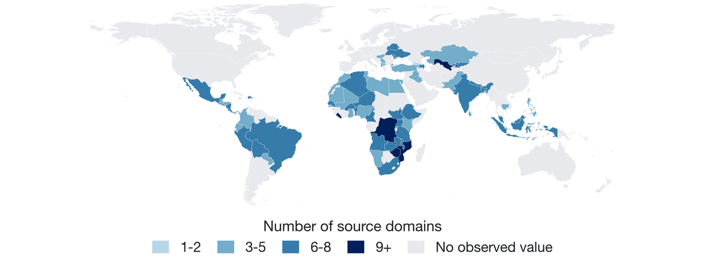

**3,181,113 eligible articles** · **26 international / mixed-country domains** also included.

## Prompting: government, action, evaluation

1

### Which government?

The national incumbent  
at publication.

2

### What happened?

The main reported action.  
Who did what to whom?

3

### How is it evaluated?

1. Political alignment
2. Reputational implication
3. Framing

**Input to the model:** title and text, publication country, date and source domain.

## GenAI validation (Astra-assisted)

**173 articles where human and GenAI selected the same action**

| Judgment | Supported | Defensible | Scope issue | Revise |
| --- | --- | --- | --- | --- |
| Political alignment | **89.6%** | 0.6% | 1.2% | 8.7% |
| Reputational implication | **86.1%** | 5.8% | 1.2% | 6.9% |
| Framing | **93.1%** | 1.7% | 1.2% | 4.0% |

## Most eligible articles have zero-coded labels

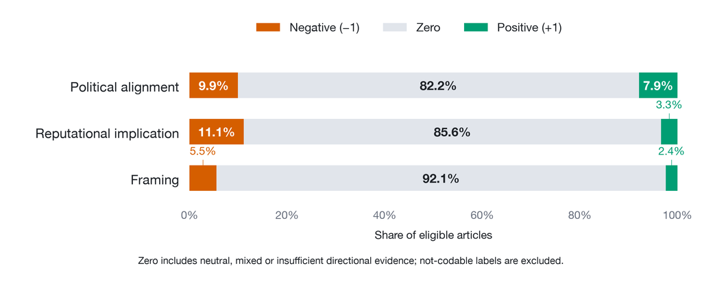

## Positive alignment, negative reputational implication

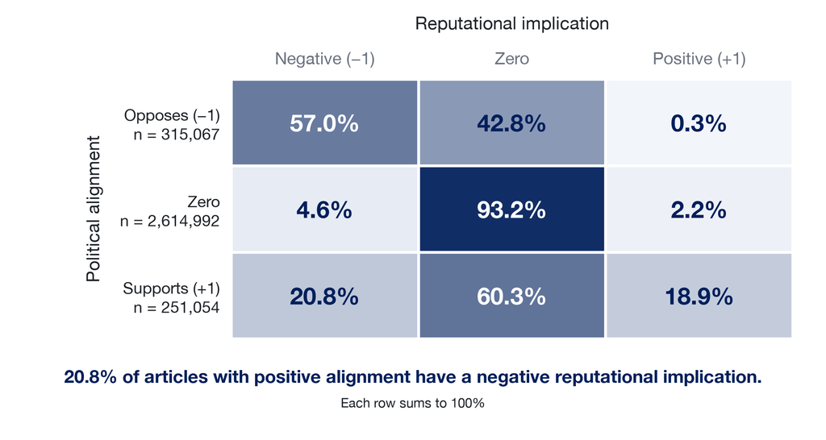

## Application 1: polarization across countries

Evaluated governments · All source origins · January 2022–May 2026 · Ukraine excluded

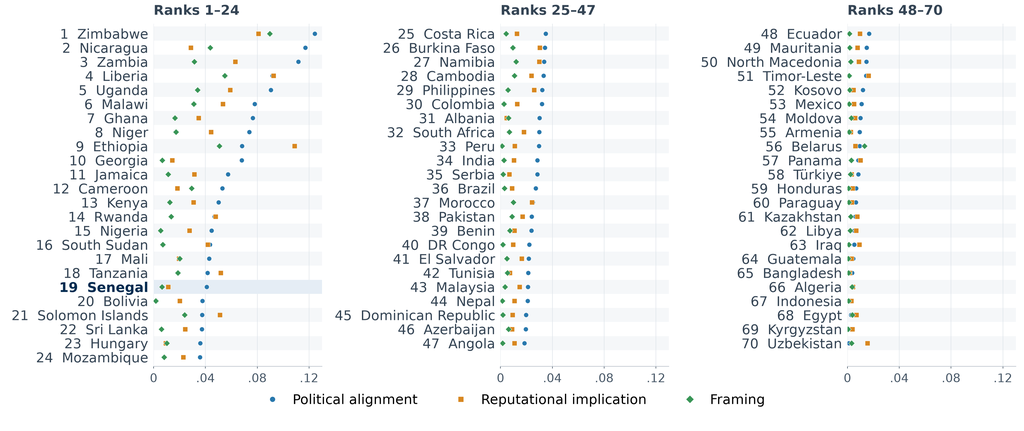

**P = 4 × p₊ × p₋**. Positive and negative article shares; zero-coded articles stay in the denominator.

## Alignment and reputation across regime types

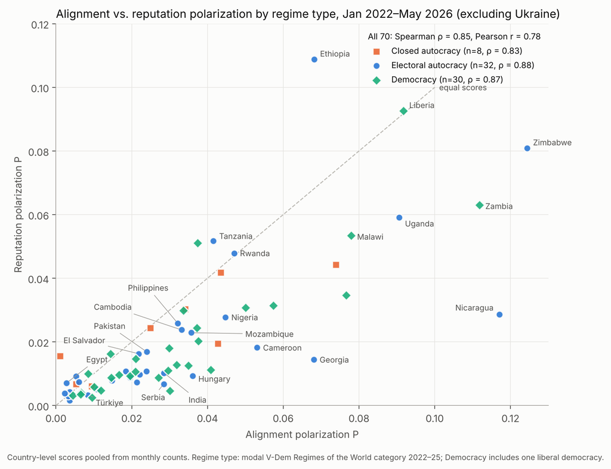

Evaluated governments · All source origins · One point per country

## Senegal: coverage shifts across the election crisis

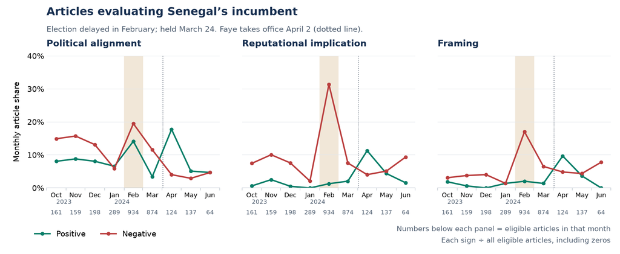

February → March: articles with **positive or negative political alignment** fall from **33.6% to 15.0%**.

## Senegal: polarization and salience

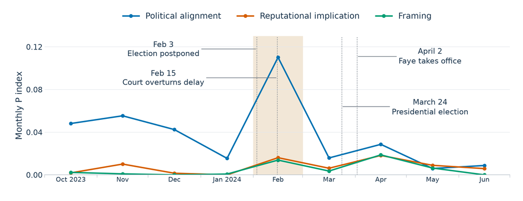

**P = 4 × p₊ × p₋**p₊ and p₋ are the positive and negative article shares.

## Senegal: Actor groups and action tags

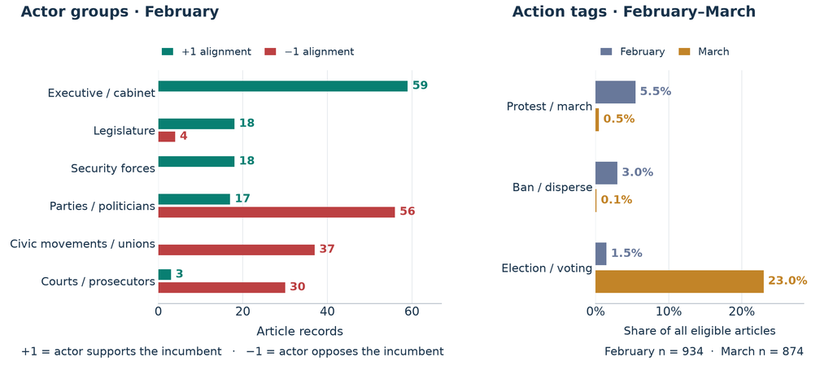

## Senegal: connecting the labels to reported actions

### Sall postpones the election

Sud · February 7

Political alignment **+1** · Reputational implication **−1** · Framing **−1**

“Dangerous Game” adds criticism to the reported executive action.

### GERDDES-Africa condemns the governing majority

Xalima · February 7

Political alignment **−1** · Reputational implication **−1** · Framing **0**

The quoted actor criticizes the government. The narrator need not.

### Court overturns the postponement

France24 · February 15

Political alignment **−1** · Reputational implication **−1** · Framing **0**

A state institution constrains the incumbent.

### Voters go to the polls

BBC · March 24

Political alignment **0** · Reputational implication **0** · Framing **0**

Voting does not automatically imply support or opposition.

## Zimbabwe: the same incumbent, different framing

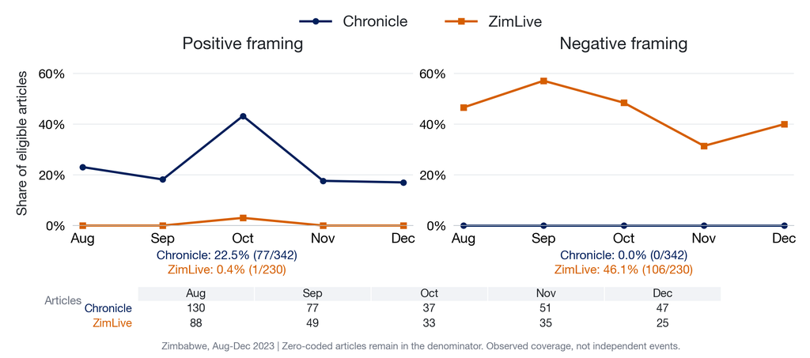

Chronicle, September 14: **“hits the ground running”** → framing **+1**.  
Positive and negative shares show differences that a two-sided index can conceal.

## The same court decision, different portrayals

**September 15, 2023: bail for opposition candidate Patrick Cheza**

### Chronicle

> “Sore loser…Road Rage”

Framing **+1**

Ridicules the government’s opponent.

### ZimLive

> “ends jail nightmare”

Framing **−1**

Emphasizes the opponent’s detention.

Both articles: political alignment 0 · reputational implication 0

## Application 2: foreign governments

When the evaluated government differs from the country of publication

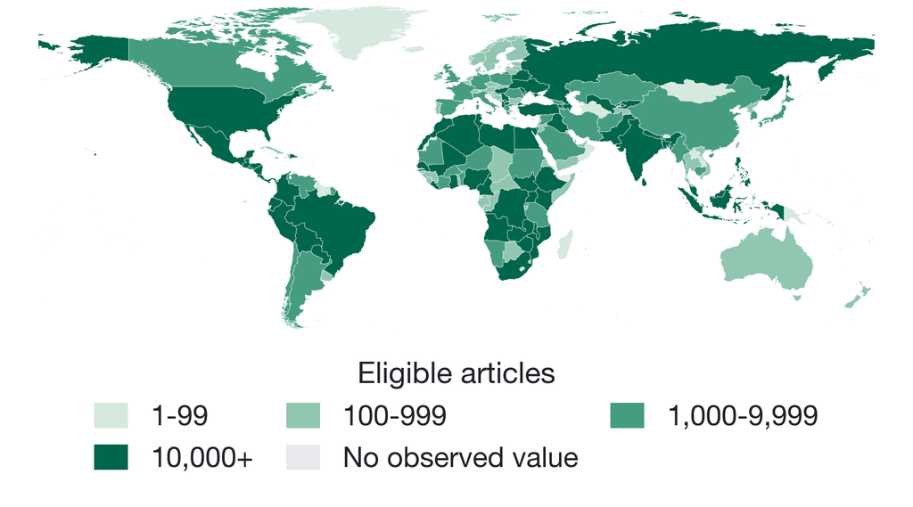

**211 evaluated-government country / territory codes**

- Does the **same outlet** portray different governments differently?
- Does coverage differ for **allies and rivals**?
- Which **actors and actions** explain the differences?

## One outlet, two governments

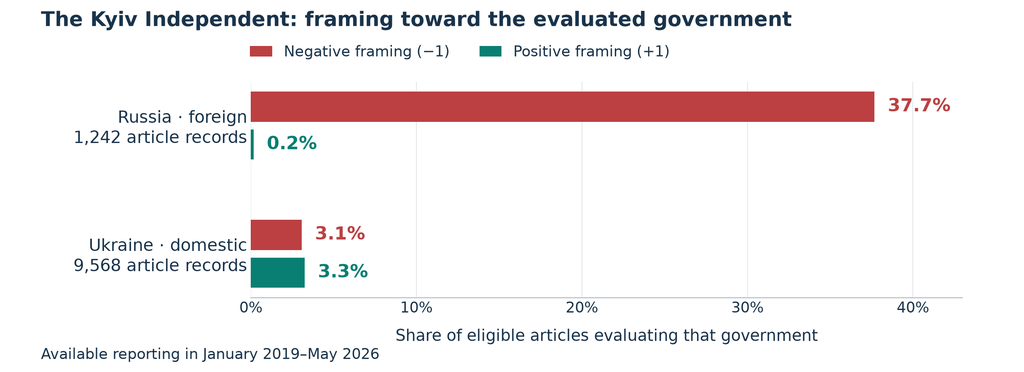

Russia receives more negative framing in this sample. The underlying events also differ.

## Application 3: press freedom and coverage

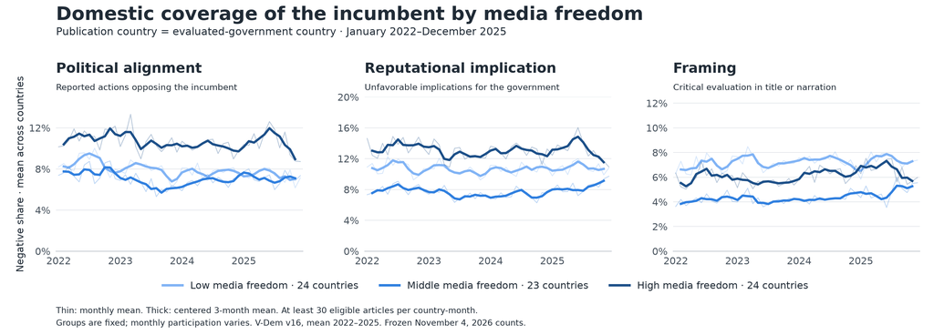

The group ordering differs across the three judgments.

**The low-freedom framing average is strongly influenced by Nicaragua.**

## Nicaragua: framing differs across outlets

Framing toward Nicaragua’s government · Six largest sampled outlets · 2022–2025

| Outlet | Articles | Negative framing | Positive framing |
| --- | --- | --- | --- |
| Artículo 66 | 1,832 | **71.4%** | 0.2% |
| La Prensa | 1,445 | **54.3%** | 0.3% |
| Confidencial | 988 | **65.1%** | 0.0% |
| Onda Local | 233 | **70.8%** | 0.0% |
| Nueva Radio Ya | 473 | 0.0% | **17.3%** |
| Canal 2 | 328 | 0.0% | **8.5%** |

**Including Nicaragua raises the low-freedom negative-framing average: 5.16% → 7.23%.**

## Coverage varies across outlets

Domestic coverage · 401 outlets · January 2022–December 2025

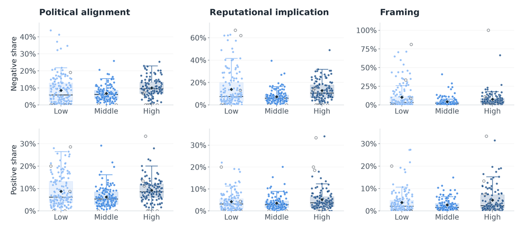

Groups: media freedom. Box: middle 50%; line: median; diamond: mean. Open circles: fewer than 30 articles. Panel scales differ.

**Negative coverage varies more across low-freedom outlets.**

## Discussion

**How can we identify polarization in news coverage?**

Persistent divisions among actors, between outlets, or both?

**Which kinds of media bias can we identify, and how?**

Which events and actors are selected; how comparable events are framed.

**How do regime type and press freedom shape what we observe?**

Fewer civic actions, less reporting of them, or different framing?

Supported by the **Penn MEDIATED Research Grant Program**.

## Appendix: choosing the same reported action

**Three-way comparison · the same 251 reviewable articles**

| Comparison | Same action | Agreement |
| --- | --- | --- |
| Human–Luna | 179 / 251 | **71.3%** |
| Human–review reference | 184 / 251 | **73.3%** |
| Luna–review reference | 221 / 251 | **88.0%** |

First establish **what was selected**. Then compare its political labels.

## Appendix: where action choices differ

| On the common 251 articles | Articles |
| --- | --- |
| All three select the same action | **172** |
| Only Luna matches the review reference | **49** |
| Only the human matches the review reference | **12** |
| Human and Luna agree; reference differs | **7** |
| All three select different actions | **11** |

Among both choosing an action: **173 / 213 agree (81.2%)**.  
Including explicit no-action choices: **184 / 264 agree (69.7%)**.

## Appendix: other fields after choosing the same action

**173 shared actions · compare each field where both values are available**

| Recorded field | Human–Luna matches |
| --- | --- |
| Main action category | 109 / 173 · **63.0%** |
| All action categories | 100 / 173 · **57.8%** |
| Actor category | 108 / 157 · **68.8%** |
| Exact actor wording | 48 / 154 · **31.2%** |
| Prior action triggering this action | 9 / 20 · **45.0%** |
| Evaluated government | 5 / 13 · **38.5%** |

## Appendix: checking positive and negative labels

| Label supported | All labels | Only +1 / −1 labels |
| --- | --- | --- |
| Political alignment | 155 / 173 · **89.6%** | 28 / 41 · **68.3%** |
| Reputational implication | 149 / 173 · **86.1%** | 16 / 31 · **51.6%** |
| Framing | 161 / 173 · **93.1%** | 12 / 21 · **57.1%** |

Most labels are zero. Defensible alternatives remain in the denominators.

## Appendix: what stronger research claims require

| What we want to establish | What we need next |
| --- | --- |
| **The codes capture the intended distinctions** | Independent human coding of all three dimensions, including enough positive and negative cases and checks against original-language text. |
| **Outlets systematically portray governments differently** | Repeated comparisons of the same events. Separate action selection, quoted voices and narrator wording. |
| **The media environment relates to political polarization** | Compare news measures with independent evidence on political actors or citizens. Keep coverage direction, its prevalence and disagreement separate. |

The current findings identify comparisons worth testing. Source differences alone do not establish bias, its causes or its effects on citizens.

## References

Abramowitz, Alan I., and Kyle L. Saunders. 2008. “Is Polarization a Myth?” *The Journal of Politics* 70(2): 542–55.

Boxell, Levi, Matthew Gentzkow, and Jesse M. Shapiro. 2024. “Cross-Country Trends in Affective Polarization.” *The Review of Economics and Statistics* 106(2): 557–65. doi:10.1162/rest_a_01160.

Coppedge, Michael, John Gerring, Carl Henrik Knutsen, Staffan I. Lindberg, Jan Teorell, et al. 2025. “V-Dem [Country-Year/Country-Date] Dataset V15.” doi:10.23696/vdemds25.

Dalton, Russell J. 2008. “The Quantity and the Quality of Party Systems: Party System Polarization, Its Measurement, and Its Consequences.” *Comparative Political Studies* 41(7): 899–920.

Fiorina, Morris P., and Samuel J. Abrams. 2008. “Political Polarization in the American Public.” *Annual Review of Political Science* 11: 563–88.

Gentzkow, Matthew, and Jesse M. Shapiro. 2010. “What Drives Media Slant? Evidence from U.S. Daily Newspapers.” *Econometrica* 78(1): 35–71. doi:10.3982/ECTA7195.

Gentzkow, Matthew, Jesse M. Shapiro, and Matt Taddy. 2019. “Measuring Group Differences in High-Dimensional Choices: Method and Application to Congressional Speech.” *Econometrica* 87(4): 1307–40.

Graham, Matthew H., and Milan W. Svolik. 2020. “Democracy in America? Partisanship, Polarization, and the Robustness of Support for Democracy in the United States.” *American Political Science Review* 114(2): 392–409. doi:10.1017/S0003055420000052.

Iyengar, Shanto, Yphtach Lelkes, Matthew Levendusky, Neil Malhotra, and Sean J. Westwood. 2019. “The Origins and Consequences of Affective Polarization in the United States.” *Annual Review of Political Science* 22: 129–46.

Kim, Eunji, Yphtach Lelkes, and Joshua McCrain. 2022. “Measuring Dynamic Media Bias.” *Proceedings of the National Academy of Sciences* 119(32): e2202197119. doi:10.1073/pnas.2202197119.

Kubin, Emily, and Christian von Sikorski. 2021. “The Role of (Social) Media in Political Polarization: A Systematic Review.” *Annals of the International Communication Association* 45(3): 188–206. doi:10.1080/23808985.2021.1976070.

Lauka, Alban, Jennifer McCoy, and Rengin B. Firat. 2018. “Mass Partisan Polarization: Measuring a Relational Concept.” *American Behavioral Scientist* 62(1): 107–26. doi:10.1177/0002764218759581.

Lelkes, Yphtach. 2016. “Review: Mass Polarization: Manifestations and Measurements.” *The Public Opinion Quarterly* 80: 392–410. https://www.jstor.org/stable/44014625 (November 10, 2026).

Levendusky, Matthew S. 2013. “Why Do Partisan Media Polarize Viewers?” *American Journal of Political Science* 57(3): 611–23.

Martin, Gregory J., and Ali Yurukoglu. 2017. “Bias in Cable News: Persuasion and Polarization.” *American Economic Review* 107(9): 2565–99. doi:10.1257/aer.20160812.

McCarty, Nolan, Keith T. Poole, and Howard Rosenthal. 2006. *Polarized America: The Dance of Ideology and Unequal Riches*. Cambridge, MA: MIT Press.

Poole, Keith T., and Howard Rosenthal. 1985. “A Spatial Model for Legislative Roll Call Analysis.” *American Journal of Political Science* 29(2): 357–84.

Popescu, Marina, Gábor Tóka, Tania Gosselin, and Jose Santana Pereira. 2011. “European Media Systems Survey 2010: Results and Documentation.”

Prior, Markus. 2013. “Media and Political Polarization.” *Annual Review of Political Science* 16: 101–27. doi:10.1146/annurev-polisci-100711-135242.

Puglisi, Riccardo, and James M. Snyder. 2015. “Chapter 15 - Empirical Studies of Media Bias.” In *Handbook of Media Economics*, Handbook of media economics, eds. Simon P. Anderson, Joel Waldfogel, and David Strömberg. North-Holland, 647–67. doi:10.1016/B978-0-444-63685-0.00015-2.

Reiljan, Andres. 2020. “‘Fear and Loathing Across Party Lines’ (Also) in Europe: Affective Polarisation in European Party Systems.” *European Journal of Political Research* 59(2): 376–96. doi:10.1111/1475-6765.12351.

Somer, Murat, Jennifer L. McCoy, and Russell E. Luke. 2021. “Pernicious Polarization, Autocratization and Opposition Strategies.” *Democratization* 28(5). doi:10.1080/13510347.2020.1865316.

Svolik, Milan W. 2019. “Polarization Versus Democracy.” *Journal of Democracy* 30(3): 20–32.

Wagner, Markus. 2021. “Affective Polarization in Multiparty Systems.” *Electoral Studies* 69: 102199. doi:10.1016/j.electstud.2020.102199.